# Sentiment by Audience & Tweet Length

# 3 Deeper analysis

Now that things are more or less in order, let’s take a closer look at testing these two hypotheses. The first one, again, is that **angrier tweets have more `@` symbols** meaning discontent Twitter users want an audience for their displeasure. While we’re at it, we can see if the airline makes a difference.

## 3.1 Part 1

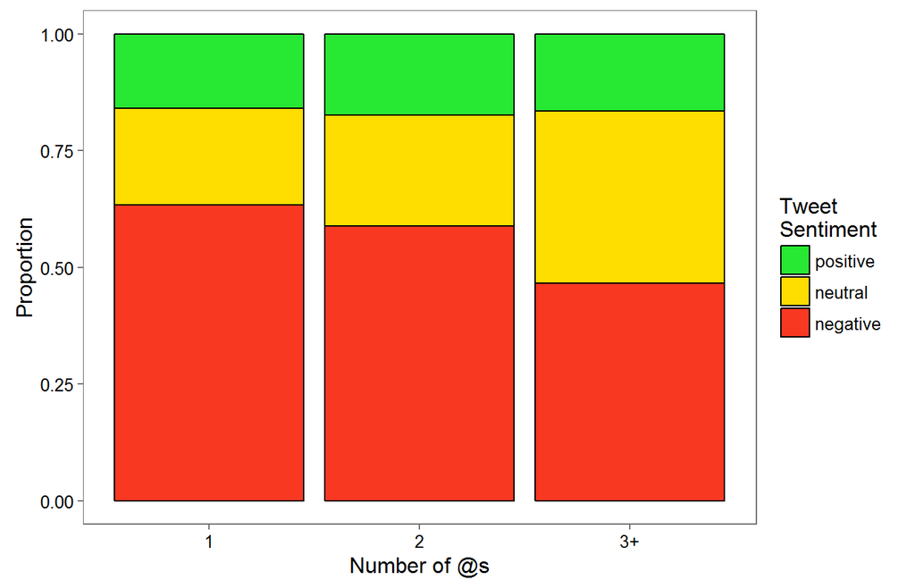

```r
# Visualize proportions of positive, neutral, and negative
# sentiment tweets by number of @ symbols used
ggplot(tweets, aes(x = at_countD, fill = airline_sentiment)) +
  geom_bar(position = 'fill', colour = 'black') +
  scale_fill_manual(name   = 'Tweet\nSentiment',
                    values = sentPlt,
                    breaks = sentBreaks) +
  labs(x = 'Number of @s', y = 'Proportion') +
  theme_few() +
  theme(text = element_text(size=12))
```

Looks like my hypothesis is not quite holding. While tweets containing 1, 2, and 3+ `@` symbols have roughly the same proportion of positive tweets, the negativity goes down and neutrality goes up. Thus, I would guess, is because the ratio of useful text to perform sentiment analysis is decreasing as the number of addressees in the text increases resulting in greater uncertainty/neutrality.

Considering the **airline** itself as a variable.

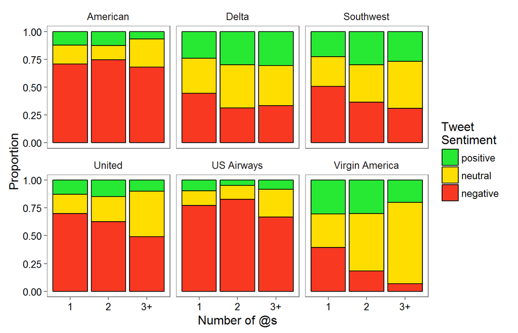

```r
# Visualize the same plot as before but add airline
ggplot(tweets, aes(x = at_countD, fill = airline_sentiment)) +
  geom_bar(position = 'fill', colour = 'black') +
  facet_wrap(~airline) +
  scale_fill_manual(name   = 'Tweet\nSentiment',
                    values = sentPlt,
                    breaks = sentBreaks) +
  labs(x = 'Number of @s', y = 'Proportion') +
  theme_few() +
  theme(text = element_text(size=12))
```

## 3.2 Part 2

I’m ready to move on to looking at **tweet length** as our variable of interest. As we saw before, it appeared that the distribution of negative sentiment tweets was shifted rightward towards longer tweets in comparison to neutral and positive distributions. What does it look like for the six airlines?

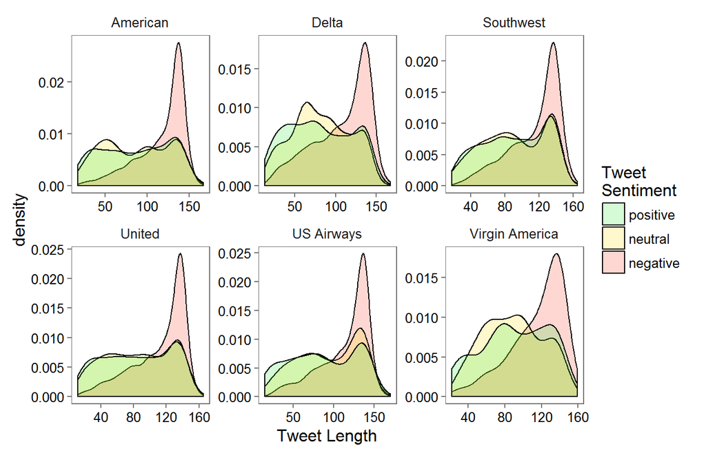

```r
ggplot(tweets, aes(x = text_length,
    fill = airline_sentiment)) +
  geom_density(alpha = 0.2) +
  facet_wrap(~airline, scale = 'free') +
  scale_fill_manual(name   = 'Tweet\nSentiment',
                    values = sentPlt,
                    breaks = sentBreaks) +
  labs(x = 'Tweet Length') +
  theme_few() +
  theme(text = element_text(size=12))
```

# 4 Conclusion